# The DAVID Pipe

Sumeed Yoyo Manzoor [Chang Lab](https://changlab.uchicago.edu) at the University of Chicago

15 Apr, 2020

# Introduction

This notebook will go through the pipeline that led to the data exports for DAVID.

*Note that most linked GitHub repos are currently private. Email me for access*.

This pipe was developed in many different parts, but I will attempt to consolidate all the code snippets and tools that led to the most current iteration of the pipe, starting from downloading the data from the genomics core, to getting feature counts from [RNASeq Alignment](https://github.com/Yoyomanzoor/RNASeqAlign), to [cleaning up the featurecounts data](https://github.com/Yoyomanzoor/RNA-SEQualizer/tree/master/code/Python) in python, to [finding oscillating genes](https://github.com/Yoyomanzoor/eJTK) on Midway, to [subsetting data](https://github.com/Yoyomanzoor/RNA-SEQualizer/blob/master/code/R/DAVID%20export.R) from eJTK for DAVID in R. Linked are the original code locations.

A note about the many repos:

- RNA-SEQualizer is the main repo for all analysis *not* run on the Midway server.
- RNASeqAlign is the repo on Midway for running STAR alignment + featurecounts.
- eJTK is the repo on Midway for running eJTK_CYCLE.

```
/
│
├─code/
│ ├─Python/                 # Contains python-developed tools, mostly for subsetting featurecounts
│ ├─R/                      # Contains R-developed tools
│ │ ├─DAVID pipe/           # All materials for this DAVID pipe document
│ │ ├─py/                   # py scripts called by reticulate in R
│ │ │ ├─DAVID.py
│ │ ├─tutorial/             # DESeq2 -> fGSEA tutorial
│ │ ├─DAVID export.R        # R script originally made for exporting lists for DAVID
├─data/
│ ├─DAVID/                  # Where the lists for importing to DAVID are stored
│ ├─R/
│ │ ├─eJTK_output/          # input and output from eJTK
│ │ │ ├─WT_SPF_OTHERTEXT_jtkout_GammaP.txt
│ │ │ ├─KO_SPF_OTHERTEXT_jtkout_GammaP.txt
│ │ │ ├─WT_GF_OTHERTEXT_jtkout_GammaP.txt
│ │ │ ├─KO_GF_OTHERTEXT_jtkout_GammaP.txt
├─KF_RNAseq_counts.txt      # Featurecounts table from RNA Seq alignment
```

# Generating featurecounts using STAR alignment

## Obtaining data

Data was obtained from the Genomics core as FASTQ files.  
On the [genomics core website](https://fgf.uchicago.edu/), the files are:

```
/
│
├─190715_K00242_0584_AH7GWCBBXY-EC-KF-RS72-2lns     # 7/23/19, 2 lanes
├─191002_K00242_0622_AHF3VKBBXY-EC-KF-RS72-ln2      # 10/3/19, 1 lane
├─191004_K00242_0623_AHF5CTBBXY-EC-KF-RS72-lns456   # 10/7/19, 3 lanes
```

There are a total of 6 lanes.  
Data was downloaded to the Lab Mac, where data prep was run. The folders remained in the above file structure to run the data prep below.

## Data prep

Data prep was to join all lanes into a single file for each sample, and have each of these files in its own folder. This was accomplished using 3 scripts. `FileEdits1.py` renamed all `fastq.gz` files in the working directory to a simpler name - “initials_samplenumber_lanenumber.fastq.gz”. The script depends on the files following the correct order for renaming. This can be checked by running `sorted(glob.glob('*.fastq.gz'))` in the directory, which should output a list with the correct order of files (order of increasing lanes, increasing sample numbers). `FileEdits2.py` takes all the renamed files and sorts them into individual folders for each sample, containing all lanes for that sample. `concatenate.sh` concatenates all lanes into a single file.

I will show the scripts, along with the expected file structures at each stage.

Before running the script, the number of lanes in the current folder, the lane to start relabeling with, and the total number of lanes must be updated in the scripts. See the comments in the scripts.

`FileEdits1.py` is run in each folder downloaded from genomics core separately. For example, it was first run like this:

```
/
│
├─190715_K00242_0584_AH7GWCBBXY-EC-KF-RS72-2lns/
│ ├─FileEdits1.py
│ ├─*.fastq.gz                                      # all fastq.gz files for this RNA Seq run
├─191002_K00242_0622_AHF3VKBBXY-EC-KF-RS72-ln2/
├─191004_K00242_0623_AHF5CTBBXY-EC-KF-RS72-lns456/
```

Then, like this:

```
/
│
├─190715_K00242_0584_AH7GWCBBXY-EC-KF-RS72-2lns/
├─191002_K00242_0622_AHF3VKBBXY-EC-KF-RS72-ln2/
│ ├─FileEdits1.py
│ ├─*.fastq.gz                                      # all fastq.gz files for this RNA Seq run
├─191004_K00242_0623_AHF5CTBBXY-EC-KF-RS72-lns456/
```

`FileEdits1.py`

```python
#!/usr/bin/env python

import os
import glob
import shutil
import sys

files = sorted(glob.glob('*.fastq.gz'))

initials = "KF" # Change to your initials
lanes = 2       # Change depending on the number of lanes in the current directory.
l_start = 2     # Change to the first lane in to begin relabeling with. E.g. if there are 3 lanes, lanes 4, 5, & 6, then this should be set to 4.
new_names = []

for i in range(int(len(files)/lanes)):
    if i < 9:
        for j in range(lanes):
            new_names.append(initials + '_S0' + str(i+1) + '_L' + str(j+l_start) + '.fastq.gz')
    else:
        for j in range(lanes):
            new_names.append(initials + '_S' + str(i+1) + '_L' + str(j+l_start) + '.fastq.gz')

if len(new_names) != len(files):    # should be true to proceed to renaming
    sys.exit('generating new names failed')

i = 0
for file in sorted(glob.glob('*.fastq.gz')):
    os.rename(file, new_names[i])
    i += 1
```

The file structure will be unchanged. The files will simply all be renamed. They can then be moved into one central folder, as such:

```
/
│
├─FileEdits2.py
├─*.fastq.gz                                        # all fastq.gz files from all folders
```

`FileEdits2.py`

```python
#!/usr/bin/env python

import os
import glob
import shutil

files = sorted(glob.glob('*.fastq.gz'))
total_lanes = 6     # Change to the total number of lanes in the directory

def makedirectory(dirname):
    if not os.path.exists(dirname):    # Make output directory if it doesn't exist
        os.makedirs(dirname)

k = 0
for i in range(1,73):
    for j in range(total_lanes):
        if i < 10:
            dir = '0' + str(i)
            makedirectory(dir)
            shutil.move(files[k], dir + '/' + files[k])
        else:
            dir = str(i)
            makedirectory(dir)
            shutil.move(files[k], dir + '/' + files[k])
        k += 1
```

The resulting file structure should be:

```
/
│
├─concatenate.sh
├─01                                            # sample 1
│ ├─KF_S01_L1.fastq.gz
│ ├─KF_S01_L2.fastq.gz
│ ├─KF_S01_L3.fastq.gz
│ ├─...                                         # fastq.gz files for all lanes in sample 1
├─02                                            # sample 2
│ ├─KF_S02_L1.fastq.gz
│ ├─KF_S02_L2.fastq.gz
│ ├─KF_S02_L3.fastq.gz
│ ├─...                                         # fastq.gz files for all lanes in sample 2
├─03                                            # sample 3
├─...                                           # repeating pattern
```

Lanes can then be concatenated into single files using a bash script `concatenate.sh`. It parses through all folders and joins all `fastq.gz` files into one file.

`concatenate.sh`

```bash
#!/bin/bash

for d in */
do
    cd "$d"
    for i in *.fastq.gz
    do
        cat "$i" >> KF_S${d:0:2}.fastq.gz && rm "$i" || break   # Change 'KF' to your initials
    done
    cd ..
done
```

#### Troubleshooting

Any references to “KF” should be replaced with the correct initials for the experiment.  
`FileEdit2.py` and `concatenate.sh` only need to be run once, but `FileEdit1.py` needs to be manually edited and run in every directory.  
`FileEdit2.py` requires all files to be in a working folder from which the script is run.

## STAR Alignment

[useful link](https://github.com/hbctraining/Intro-to-rnaseq-hpc-O2/tree/master/lessons)

Alignment was done on the Midway server at `/project2/ebchang/Yoyo/RNASeqAlign`. There are two steps, alignment then featurecount generation.

### Dependencies

The only code dependencies lie with `get_queue.py`, which requires `python==3.6.8` with `numpy==1.17.2` and `pandas==0.25.2`. These can be installed in a conda environment locally on Midway using `conda`. *Remember that `base` env in Midway is python 2.7, not python 3.7*.

Beyond that, the reference genome must be in a folder in working directory called `genomeDir`.

File structure:

```
/
│
├─data/                             # place fastq.gz files here
├─genomeDir/                        # place genome here
├─align_STAR_KF.sbatch
├─parallel_align_STAR_KF.sh
├─get_queue.py
```

Check code comments for important notices.

### Alignment

There are three scripts put together that run the alignment.

```
align_STAR_KF.sbatch            # Runs the alignment for the individual files

parallel_align_STAR_KF.sbatch   # A shell wrapper for align_STAR_KF.sbatch to run multiple alignments at a time

get_queue.py                    # Python script to prevent running too many files at once and getting banned from Midway
```

`align_STAR_KF.sbatch`

```bash
#!/bin/bash

#SBATCH --job-name=star_align
#SBATCH --output=VARIABLE
#SBATCH --error=VARIABLE
#SBATCH --time=8:00:00
#SBATCH --partition=broadwl
#SBATCH --nodes=1
#SBATCH --ntasks-per-node=6
#SBATCH --mem-per-cpu=6000

#---------------------------------------------------------------
# Written by Mirae Lee 08/2019, Edited by Sumeed Yoyo Manzoor
# For aligning RNAseq reads using STAR
# This script assumes you have the STAR index already made
# Change file name/locations as needed
#--------------------------------------------------------------

#---------------------------------------------------------------
# set working directory, resource directory, and load modules
#---------------------------------------------------------------

cd "$SBATCH_0_WORKDIR"

star_dir="/project2/ebchang/Yoyo/RNASeqAlign/"  # Change this to working directory. ${PWD} will not work.
star_index_dir="${star_dir}/genomeDir"

FILE=VARIABLE
PTH=VARIABLE
filename=${FILE%%.*}

module load STAR
module load samtools

#---------------------------------------------------------------
# STAR Alignment
#---------------------------------------------------------------

new_folder="${star_dir}/STAR_alignment/${filename}"
if [ -d "new_folder" ]; then
    cd ${star_dir}/STAR_alignment/${filename}
else
    mkdir ${star_dir}/STAR_alignment/${filename}
    cd ${star_dir}/STAR_alignment/${filename}
fi

STAR --genomeDir ${star_dir}/ \
                --readFilesIn ${FILE} \
                --runThreadN 6\
                --outFileNamePrefix ${filename}_ \
                --outSAMtype BAM SortedByCoordinate     \
```

`parallel_align_STAR_KF.sbatch`

```bash
#!/bin/sh

#--------------------------------------------------------------------------
# Written by Mirae Lee 08/2019
# Bash script to run 'align_STAR.sbatch' in parallel
# I couldn't figure out how to stop running after a certain amount of jobs
# Please only run 10 max in parallel (keep in separate folders?)
#--------------------------------------------------------------------------

#--------------------------------------------------------------------------
# Edit Yoyo 10/2019
# Goes through every folder in the data folder (${fastq_dir}) to find fastq.gz and load those into sbatch files to run on server.
# Assumes there are about 10 files per folder in the data folder, and no fastq.gz files are outside of folders.
#--------------------------------------------------------------------------


star_dir="/project2/ebchang/Yoyo/RNASeqAlign"
fastq_dir="$/project2/ebchang/Yoyo/RNASeqAlign/data/"
batchfile=${star_dir}/align_STAR_KF.sbatch

cd $fastq_dir
ls
for FOLDER in */
do
    cd ${FOLDER}
    for FILE in *.fastq.gz
        do
        cd ${star_dir}
    pathfile2=${fastq_dir}${FOLDER}
    pathfile=${fastq_dir}${FOLDER}${FILE}
    errfile="${fastq_dir}${FOLDER}errors/${FILE%%.*}"

    echo "FOLDER"
    echo ${FOLDER}
    echo "FILE"
    echo ${FILE}

    # echo "pathfile2"
    # echo ${pathfile2}
    # echo "pathfile"
    # echo ${pathfile}
    # echo "errfile"
    # echo ${errfile}

    mkdir ${fastq_dir}${FOLDER}errors/
    sed -i "4,5 s|VARIABLE|${errfile}|g" ${batchfile}
    sed -i "28 s|VARIABLE|${pathfile}|g" ${batchfile}
        sed -i "29 s|VARIABLE|${pathfile2}|g" ${batchfile}
    # sbatch ${batchfile}   # UNCOMMENT TO SUBMIT JOBS TO MIDWAY. MAKE SURE SCRIPTS WORK AS INTENDED FIRST.
    sed -i "s|${errfile}|VARIABLE|g" ${batchfile}
    sed -i "s|${pathfile}|VARIABLE|g" ${batchfile}
    sed -i "s|${pathfile2}|VARIABLE|g" ${batchfile}
    python get_queue.py
    done
    cd $fastq_dir
done
```

`get_queue.py`

```python
#!/usr/bin/env python

import subprocess
import numpy as np
import pandas as pd
from io import StringIO
import time

name = 'smanzoor'   # Change this to your rcc username

while True:
    process = subprocess.Popen(['squeue','--user=' + name], stdout=subprocess.PIPE, universal_newlines=True)

    f = process.stdout.read()
    f = f.replace('\n', 'slashn')
    f = ' '.join(f.split())
    f = f.replace('slashn','\n')
    f = StringIO(unicode(f))

    df = pd.read_csv(f, sep=' ')
    df = df.reset_index(drop=True)

    time.sleep(5)
    if len(df.index) < 2:
        break
    elif len(df.index) == 0:
        break
```

#### Toubleshooting

Files are expected to be gunzip’d. If they remain .gz before running, use command `--readFilesIn zcat`. See [STAR manual](https://github.com/alexdobin/STAR/blob/master/doc/STARmanual.pdf).  
`get_queue.py` depends on `squeue --user` to output a table. If the code breaks, RCC may have changed formatting of the squeue output.  
Also, `sed` in `parallel_align_STAR_KF.sbatch` calls specific lines in `align_STAR_KF.sbatch`, so that may be a source of breaking.

### Featurecounts

Alignment should produce a folder containing all the `bam` files.

`featureCounts.sbatch`

```bash
#!/bin/sh

#SBATCH --job-name=featureCounts
#SBATCH --output=/project2/ebchang/Katya/ML_analysis/KF_LOGS/featureCounts_log.out
#SBATCH --error=/project2/ebchang/Katya/ML_analysis/KF_LOGS/featureCounts_log.err
#SBATCH --time=8:00:00
#SBATCH --partition=broadwl
#SBATCH --nodes=1
#SBATCH --ntasks-per-node=2
#SBATCH --mem-per-cpu=2000

#---------------------------------------------------------------
# Written by Mirae Lee 08/2019
# For counting RNAseq reads after STAR alignment with featureCounts
# To submit to SLURM when you have many files
# This script assumes you have completed STAR alignment
#   and that all bam files are within a central folder
# Change file name/locations as needed
#--------------------------------------------------------------

#---------------------------------------------------------------
# set working directory, resource directory, and load modules
#---------------------------------------------------------------

ref_dir=${PWD}
star_align_dir="${PWD}/STAR_alignment"

BAM_LIST=`find ${star_align_dir} -type f -name "*.bam"`

#---------------------------------------------------------------
# run featureCounts
#---------------------------------------------------------------

        echo "Mapping ${BAM_LIST}"
        featureCounts ${BAM_LIST}\
                -a ${ref_dir}/Mus_musculus.GRCm38.97.gtf \
                -t exon \
                -g gene_id \
        -T 2 \
                -o KF_RNAseq_counts.txt \
```

`Mus_musculus.GRCm38.97.gtf` is the name of the reference genome. Change it appropriately.  
Rename `KF_RNAseq_counts.txt` to whatever you want the output to be called.

# Prepping data for eJTK

## Dependencies

- python==3.7
- numpy
- pandas
- feather (optional, if not used, gene expression data filepaths may need to be updated from `.feather` to `.csv` in downstream scripts)

## Code

Data was prepared in python. It makes several assumptions of the experimental setup to work: - There are the same number of replicates for each condition at each time period - The time between replicates is consistent for the entire experiment

This file also swaps the data for KF_17 and KF_21.

`RNA Seq Counts Data Processing.py`

```python
import os
from io import StringIO
import numpy as np
import pandas as pd
import feather as ft
from File_Export import *

data = 'KF_RNAseq_counts.txt'
number_of_conditions = 4    # number of conditions in the experiment
timepoints = 6              # total number of time points in the experiment
t_d = 4                     # amount of time between each time point (in hours)
initial_time = 2            # initial time (Zeitgeber time) that the experiment starts

directory = 'data'
if not os.path.exists(directory):    # Make output directory if it doesn't exist
    os.makedirs(directory)

def write_dataset_to_file(dataframe, filename, directory=directory):
    filename = directory + '/%s' % filename
    filepath = '%s.feather' % filename
    ft.write_dataframe(dataframe, filepath)    # write to feather
    # filepath = '%s.csv' % filename
    # dataframe.to_csv(filepath, sep='\t',index=False)    # write to csv

def write_dataset_to_txt(dataframe, filename, directory=directory):
    """function to write datasets to csv. Datasets are saved in directory"""
    filename = directory + '/%s' % filename
    filepath = '%s.txt' % filename
    dataframe.to_csv(filepath, sep=' ', index=None)    # write to txt

f = open(data, 'r').read()
f = f.split('\n', 1)[1]

# Read in data frame from string (converted to filetype using StringIO)
df = pd.read_csv(StringIO(f), sep='\t', header=0)
# Remove Chr, Start, End, Strand, and Length columns (columns 1-5, indexed 1:6).
# Output dataframe:
#   0   | 1 | 2 | 3...
# ------|---|---|---
#  Gene | counts
df = df.drop(df.columns[1:6], axis=1)

# Make a list that will take the names from the file path name. This is done by splitting files by '/' then selecting the 6th element, which is 'KF_(some integer)'.
# Example file path: /project2/ebchang/Katya/ML_analysis/STAR_alignment/KF_46/KF_46_Aligned.sortedByCoord.out.bam
col_names = ['Geneid']    # define list, already containing the first column so the dimensions will be the same as the dataframe
for i in list(df):
    if i == 'Geneid':    # I don't want the column that contains Gene ids
        next
    else:
        label = i.split('/')[6]
        col_names.append(label)

df.columns = col_names

# Making labels to reorder the dataframe to be, like, actually sensible
new_order = ['Geneid']
for i in range(0,(len(df.columns)-1)):
    k = i+1
    if k < 10:
        new_order.append(label.split('_')[0] + '_0%s' % k)    # To align with already existing column names, which have '01'-'09' as opposed to '1'-'9'
    else:
        new_order.append(label.split('_')[0] + '_%s' % k)

df = df.reindex(columns=new_order)

# Swap column a with column b, in this case KF_17 with KF_21
a = 'KF_17'
b = 'KF_21'
df['temp'] = df[a]
df[a] = df[b]
df[b] = df['temp']
df = df.drop('temp', axis=1)

# Remove rows that have 0s only (ignores first column, gene id)
df = df.loc[(df[df.columns[1:]]!=0).any(axis=1)]

# Gets col names as needed in eJTK
def get_col_names(dataframe,samples_per_condition,timepoints,initial_time,delta_time):
    col_names = ['#']    # initialize columns with first column as '#'
    for i in range(len(list(dataframe))-1):    # iterate through every column, ignoring Gene id
        if not i % samples_per_condition:    # filter to only take # of samples/conditions to iterate through
            for k in range(timepoints):    # iterate for the entire time
                time = (delta_time*k)+initial_time
                ztime = 'ZT%s' % time
                for j in range(int(samples_per_condition/timepoints)):    # iterate for each sample measured within a timepoint
                    col_names.append(ztime)
    return col_names

def select_data(dataframe,number_of_conditions,samples_per_condition, method="NA"):
    selected_data = {}
    for i in range(number_of_conditions):
        k = i+1
        start = (samples_per_condition*i)+1
        end = (samples_per_condition*k)+1
        t = dataframe.iloc[:,start:end]
        if method == "eJTK":
            t.insert(0,'#',dataframe['#'])
        else:
            t.insert(0,'Geneid',dataframe['Geneid'])
        selected_data[i] = t
    return selected_data

sample_per_condition = int((len(list(df))-1)/number_of_conditions)    # divides number of samples by number of conditions

df_zt = df.copy()

df_zt.columns = get_col_names(df_zt,sample_per_condition,timepoints,initial_time,t_d)

selected_data = select_data(df_zt,number_of_conditions,sample_per_condition, method="eJTK")

# Export eJTK dataframes
file = ['WT_SPF','KO_SPF','WT_GF','KO_GF']
for i in range(len(file)):
    write_dataset_to_txt(selected_data[i], file[i])    # feather will not accept duplicate column names :(

dict_separate_conditions = select_data(df_zt,number_of_conditions,sample_per_condition)    # df output with log transformations

# Export transformed Circadian dataframes
file = ['R/WT_SPF_R','R/KO_SPF_R','R/WT_GF_R','R/KO_GF_R']
for i in range(len(file)):
    write_dataset_to_file(dict_separate_conditions[i], file[i])
```

This results in 4 files, ‘WT_SPF.txt’, ‘KO_SPF.txt’, ‘WT_GF.txt’, ‘KO_GF.txt’, in a `data/` folder that are curated for eJTK analysis, and 4 `.feather` files in a `data/R/` folder that are generated for use in graphing later.

# Finding oscillating genes

Oscillating genes were found using [eJTK_CYCLE](https://github.com/alanlhutchison/empirical-JTK_CYCLE-with-asymmetry). Repo found [here](https://github.com/Yoyomanzoor/eJTK). It was run on the Midway server at `/project2/ebchang/Yoyo/eJTK`.

## Dependencies

- python=2.7
- numpy
- pandas
- scipy
- matplotlib
- statsmodels  
  See eJTK github for more info

## eJTK_CYCLE setup

The program was downloaded from the [github repo](https://github.com/alanlhutchison/empirical-JTK_CYCLE-with-asymmetry) to `/project2/ebchang/Yoyo/eJTK` using `git clone git@github.com:alanlhutchison/empirical-JTK_CYCLE-with-asymmetry.git`.

Some scripts were written to submit eJTK runs to the server. The file structure is:

```
/
│
├─LOGS/                                             # created once program is run
├─bin/                                            # from git
├─data/                                             # to store files, see running eJTK
├─ref_files/                                    # from git
├─eJTK-CalcP.py                                 # from git
├─parallel_eJTK.sh
├─run_eJTK.sbatch
```

`run_eJTK.sbatch`

```bash
#!/bin/bash

#SBATCH --job-name=eJTK
#SBATCH --output=/project2/ebchang/Yoyo/eJTK/LOGS/VARIABLE.out
#SBATCH --error=/project2/ebchang/Yoyo/eJTK/LOGS/VARIABLE.err
#SBATCH --time=8:00:00
#SBATCH --partition=broadwl
#SBATCH --nodes=1
#SBATCH --ntasks-per-node=2
#SBATCH --mem-per-cpu=6000

#---------------------------------------------------------------
# Written by Yoyo
# Runs eJTK on midway for a bunch of datasets, defined in parallel_ejtk.sh
#--------------------------------------------------------------

dir="/project2/ebchang/Yoyo/eJTK"
data_dir="${dir}/data"
ref_dir="${dir}/ref_files"

FILE=VARIABLE
filename=${FILE%%.*}

#---------------------------------------------------------------
# eJTK
#---------------------------------------------------------------

${dir}/eJTK-CalcP.py -f ${data_dir}/VARIABLE -w ${ref_dir}/waveform_cosine.txt -p ${ref_dir}/period24.txt -s ${ref_dir}/phases_00-20_by4.txt -a ${ref_dir}/asymmetries_04-20_by4.txt -x OTHERTEXT
```

`parallel_eJTK.sh`

```bash
#!/bin/bash

wdir="/project2/ebchang/Yoyo/eJTK"
batchfile="${wdir}/run_eJTK.sbatch"

cd ${wdir}/data
for FILE in *.txt
do
    echo "Running ${FILE%%.*}"
    cd ${wdir}
    sed -i "s/VARIABLE/${FILE}/g" ${batchfile}
    sbatch ${batchfile}
    sed -i "s/${FILE}/VARIABLE/g" ${batchfile}
    sleep 1
done
```

## Running eJTK

Recommended to keep a copy of the original data in a folder not in `data`, and copy them into the `data` folder every time eJTK is run. When I ran this, I took the 4 text outputs from the python scripts prior.

1. python environment must be activated
2. clear `data` and `LOGS` via `rm data/* LOGS/*`
3. place your data into the `data` folder *(do not load more than 10 items in the data folder)*
4. if not done yet, make `parallel_eJTK.sh` executable via `chmod +x parallel_eJTK.sh`
5. run by command `./parallel_eJTK.sh`

Files are outputted into the `data/` folder. The only needed output ends with `jtkout_GammaP`.

# Subsetting data for DAVID

Next, the eJTK outputs are evaluated in `R` to subset data. The remaining code will be functional in the notebook, since no external tools are needed here on out.

## Setup

Some variables to declare.  
`fp` is filepath to data.  
`infile` is a marker for end of the files to read in.  
`dataFolder` is the filepath for the output

```r
fp <- 'data/'
infile <- '_OTHERTEXT_jtkout_GammaP.txt'
dataFolder <- 'out/'

WT_SPF <- 'WT_SPF'
KO_SPF <- 'KO_SPF'
WT_GF <- 'WT_GF'
KO_GF <- 'KO_GF'
```

Pull a list of all Mouse protein coding genes, including ensembl gene id, gene names, and gene descriptions.

```r
mouseProteinCodingGenes <- useMart("ensembl") %>%
  useDataset("mmusculus_gene_ensembl",mart=.) %>%
  getBM(attributes=c("ensembl_gene_id","external_gene_name","description"), filters='biotype', values=c('protein_coding'), mart=.)
```

### Filtered lists

Taking the original dataset, produce a filtered list with the following filters:

- GammaBH < 0.05 (see correspondence with Alan)
- Sort rows by lowest p (adj) value
- Only keep genes that are protein coding

```r
WT_SPF %<>%
  paste0(fp, ., infile) %>%
  read.csv2(.,sep = '\t', stringsAsFactors = F) %>%
  dplyr::select(ID,GammaBH) %>%
  filter(as.numeric(as.character(GammaBH)) < 0.05) %>%
  arrange(as.numeric(as.character(GammaBH))) %>%
  .[rowSums(sapply(., '%in%', mouseProteinCodingGenes$ensembl_gene_id)) > 0,]

KO_SPF %<>%
  paste0(fp, ., infile) %>%
  read.csv2(.,sep = '\t', stringsAsFactors = F) %>%
  dplyr::select(ID,GammaBH) %>%
  filter(as.numeric(as.character(GammaBH)) < 0.05) %>%
  arrange(as.numeric(as.character(GammaBH))) %>%
  .[rowSums(sapply(., '%in%', mouseProteinCodingGenes$ensembl_gene_id)) > 0,]

WT_GF %<>%
  paste0(fp, ., infile) %>%
  read.csv2(.,sep = '\t', stringsAsFactors = F) %>%
  dplyr::select(ID,GammaBH) %>%
  filter(as.numeric(as.character(GammaBH)) < 0.05) %>%
  arrange(as.numeric(as.character(GammaBH))) %>%
  .[rowSums(sapply(., '%in%', mouseProteinCodingGenes$ensembl_gene_id)) > 0,]

KO_GF %<>%
  paste0(fp, ., infile) %>%
  read.csv2(.,sep = '\t', stringsAsFactors = F) %>%
  dplyr::select(ID,GammaBH) %>%
  filter(as.numeric(as.character(GammaBH)) < 0.05) %>%
  arrange(as.numeric(as.character(GammaBH))) %>%
  .[rowSums(sapply(., '%in%', mouseProteinCodingGenes$ensembl_gene_id)) > 0,]
```

## Visualization

### Venn diagram

The sets can be visualized in a Venn diagram. `dataCombinations` is a basic data structure to hold all levels of the diagram.

```r
# Put all combinations into one list
# 1 = WT SPF
# 2 = KO SPF
# 3 = WT GF
# 4 = KO GF
# n = intersect
# d = difference (in the first element, not in the second)
# d_a = difference between first element and all other groups
dataCombinations <- list(
  WT_SPF,
  KO_SPF,
  WT_GF,
  KO_GF,
  inner_join(WT_SPF,KO_SPF),
  inner_join(WT_SPF,WT_GF),
  inner_join(WT_SPF,KO_GF),
  inner_join(KO_SPF,WT_GF),
  inner_join(KO_SPF,KO_GF),
  inner_join(WT_GF,KO_GF),
  Reduce(inner_join, list(WT_SPF,KO_SPF,WT_GF)),
  Reduce(inner_join, list(WT_SPF,KO_SPF,KO_GF)),
  Reduce(inner_join, list(WT_SPF,WT_GF,KO_GF)),
  Reduce(inner_join, list(KO_SPF,WT_GF,KO_GF)),
  Reduce(inner_join, list(WT_SPF,KO_SPF,WT_GF,KO_GF)),
  setdiff(WT_SPF$ID, KO_SPF$ID),
  setdiff(KO_SPF$ID, WT_SPF$ID),
  setdiff(WT_SPF$ID, WT_GF$ID),
  setdiff(WT_GF$ID, WT_SPF$ID),
  setdiff(KO_SPF$ID, KO_GF$ID),
  setdiff(KO_GF$ID, KO_SPF$ID),
  setdiff(WT_GF$ID, KO_GF$ID),
  setdiff(KO_GF$ID, WT_GF$ID),
  Reduce(setdiff, list(WT_SPF$ID, KO_SPF$ID, WT_GF$ID, KO_GF$ID)),
  Reduce(setdiff, list(KO_SPF$ID, WT_SPF$ID, WT_GF$ID, KO_GF$ID)),
  Reduce(setdiff, list(WT_GF$ID, WT_SPF$ID, KO_SPF$ID, KO_GF$ID)),
  Reduce(setdiff, list(KO_GF$ID, WT_SPF$ID, KO_SPF$ID, WT_GF$ID))
) %>%
  set_names(c('n1','n2','n3','n4','n12','n13','n14','n23','n24','n34','n123','n124','n134','n234','n1234','d12','d21','d13','d31','d24','d42','d34','d43','d1_a','d2_a','d3_a','d4_a'))

dataC_length <- sapply(dataCombinations, nrow)

venn.plot <- draw.quad.venn(
  area1 = dataC_length[['n1']],
  area2 = dataC_length[['n2']],
  area3 = dataC_length[['n3']],
  area4 = dataC_length[['n4']],
  n12 = dataC_length[['n12']],
  n13 = dataC_length[['n13']],
  n14 = dataC_length[['n14']],
  n23 = dataC_length[['n23']],
  n24 = dataC_length[['n24']],
  n34 = dataC_length[['n34']],
  n123 = dataC_length[['n123']],
  n124 = dataC_length[['n124']],
  n134 = dataC_length[['n134']],
  n234 = dataC_length[['n234']],
  n1234 = dataC_length[['n1234']],
  category = c('WT SPF','KO SPF','WT GF','KO GF'),
  fill = c('#481567FF','#2D708EFF','#3CBB75FF','#FDE725FF'),
  cat.cex = 2
)

venn.plot   # does not plot in rmd, only works in R script
```

[figure not shown]

### Heatmaps

Heatmaps can also be generated.

Pheatmap is required. viridis is optional. Log-transformed expression data is first read in and unpacked, and variables declared.

```r
folder <- '../../../data/R/by_cond/'
df <- lapply(paste0(folder,list.files(folder, pattern = '*_R.feather')), read_feather) %>%
  set_names(c('KO_GF','KO_SPF','WT_GF','WT_SPF'))

WT_SPF_exp <- df$WT_SPF %>%
  .[rowSums(sapply(., '%in%', WT_SPF$ID)) > 0,] %>%
  arrange(factor(Geneid, WT_SPF$ID)) %>%
  set_rownames(.$Geneid) %>%
  dplyr::select(-Geneid)

KO_SPF_exp <- df$KO_SPF %>%
  .[rowSums(sapply(., '%in%', KO_SPF$ID)) > 0,] %>%
  arrange(factor(Geneid, KO_SPF$ID)) %>%
  set_rownames(.$Geneid) %>%
  dplyr::select(-Geneid)

WT_GF_exp <- df$WT_GF %>%
  .[rowSums(sapply(., '%in%', WT_GF$ID)) > 0,] %>%
  arrange(factor(Geneid, WT_GF$ID)) %>%
  set_rownames(.$Geneid) %>%
  dplyr::select(-Geneid)

KO_GF_exp <- df$KO_GF %>%
  .[rowSums(sapply(., '%in%', KO_GF$ID)) > 0,] %>%
  arrange(factor(Geneid, KO_GF$ID)) %>%
  set_rownames(.$Geneid) %>%
  dplyr::select(-Geneid)

x <- 1     # start at 1
y <- 50    # number of genes
```

Expression of top cycling genes by `gammaBH` in WT SPF mice.

```r
anno_1 <- c(rep('ZT02',3), rep('ZT06',3), rep('ZT10',3), rep('ZT14',3), rep('ZT18',3), rep('ZT22',3)) %>%
  data.frame(., row.names = c('KF_01','KF_02','KF_03','KF_04','KF_05','KF_06','KF_07','KF_08','KF_09','KF_10','KF_11','KF_12','KF_13','KF_14','KF_15','KF_16','KF_17','KF_18')
  ) %>%
  set_colnames('ZT')

temp <- do.call(cbind, lapply(WT_SPF_exp[x:y,], function (x) as.numeric(as.character(x)))) %>%
  set_rownames(row.names(WT_SPF_exp)[x:y])

geneNames <- data.frame(
  row.names(temp)[match(mouseProteinCodingGenes$ensembl_gene_id, row.names(temp))],
  mouseProteinCodingGenes$external_gene_name) %>%
  na.omit(.) %>%
  set_colnames(c('Geneid','external_gene_name')) %>%
  .[match(row.names(temp),.$Geneid),]

temp %<>% set_rownames(geneNames$external_gene_name)

temp <- temp - rowMeans(temp)    # normalizing

h1 <- pheatmap(temp, color = inferno(length(temp)-1), annotation_col = anno_1, cluster_cols = F, cluster_rows = T, main = "Top cycling genes in WT SPF")
```

Expression of top cycling genes by `gammaBH` in KO SPF mice.

```r
anno_2 <- c(rep('ZT02',3), rep('ZT06',3), rep('ZT10',3), rep('ZT14',3), rep('ZT18',3), rep('ZT22',3)) %>%
  data.frame(., row.names = sapply(c(1:18), function(x) paste0('KF_',x+18))) %>%
  set_colnames('ZT')

temp <- do.call(cbind, lapply(KO_SPF_exp[x:y,], function (x) as.numeric(as.character(x)))) %>%
  set_rownames(row.names(KO_SPF_exp)[x:y])

geneNames <- data.frame(
  row.names(temp)[match(mouseProteinCodingGenes$ensembl_gene_id, row.names(temp))],
  mouseProteinCodingGenes$external_gene_name) %>%
  na.omit(.) %>%
  set_colnames(c('Geneid','external_gene_name')) %>%
  .[match(row.names(temp),.$Geneid),]

temp %<>% set_rownames(geneNames$external_gene_name)

temp <- temp - rowMeans(temp)    # normalizing

h2 <- pheatmap(temp, color = inferno(length(temp)-1), annotation_col = anno_2, cluster_cols = F, cluster_rows = T, main = "Top cycling genes in KO SPF")
```

Expression of top cycling genes by `gammaBH` in WT GF mice.

```r
anno_3 <- c(rep('ZT02',3), rep('ZT06',3), rep('ZT10',3), rep('ZT14',3), rep('ZT18',3), rep('ZT22',3)) %>%
  data.frame(., row.names = sapply(c(1:18), function(x) paste0('KF_',x+36))) %>%
  set_colnames('ZT')

temp <- do.call(cbind, lapply(WT_GF_exp[x:y,], function (x) as.numeric(as.character(x)))) %>%
  set_rownames(row.names(WT_GF_exp)[x:y])

geneNames <- data.frame(
  row.names(temp)[match(mouseProteinCodingGenes$ensembl_gene_id, row.names(temp))],
  mouseProteinCodingGenes$external_gene_name) %>%
  na.omit(.) %>%
  set_colnames(c('Geneid','external_gene_name')) %>%
  .[match(row.names(temp),.$Geneid),]

temp %<>% set_rownames(geneNames$external_gene_name)

temp <- temp - rowMeans(temp)    # normalizing

h3 <- pheatmap(temp, color = inferno(length(temp)-1), annotation_col = anno_3, cluster_cols = F, cluster_rows = T, main = "Top cycling genes in WT GF")
```

Expression of top cycling genes by `gammaBH` in KO GF mice.

```r
anno_4 <- c(rep('ZT02',3), rep('ZT06',3), rep('ZT10',3), rep('ZT14',3), rep('ZT18',3), rep('ZT22',3)) %>%
  data.frame(., row.names = sapply(c(1:18), function(x) paste0('KF_',x+54))) %>%
  set_colnames('ZT')

temp <- do.call(cbind, lapply(KO_GF_exp[x:y,], function (x) as.numeric(as.character(x)))) %>%
  set_rownames(row.names(KO_GF_exp)[x:y])

geneNames <- data.frame(
  row.names(temp)[match(mouseProteinCodingGenes$ensembl_gene_id, row.names(temp))],
  mouseProteinCodingGenes$external_gene_name) %>%
  na.omit(.) %>%
  set_colnames(c('Geneid','external_gene_name')) %>%
  .[match(row.names(temp),.$Geneid),]

temp %<>% set_rownames(geneNames$external_gene_name)

temp <- temp - rowMeans(temp)    # normalizing

h4 <- pheatmap(temp, color = inferno(length(temp)-1), annotation_col = anno_4, cluster_cols = F, cluster_rows = T, main = "Top cycling genes in KO GF")
```

All heatmaps put together. Important to note that order (from top to bottom) of the heatmap was clustered by pheatmap and is not ordered by `gammaBH`. To have it ordered by `gammaBH`, set `cluster_rows = F`.

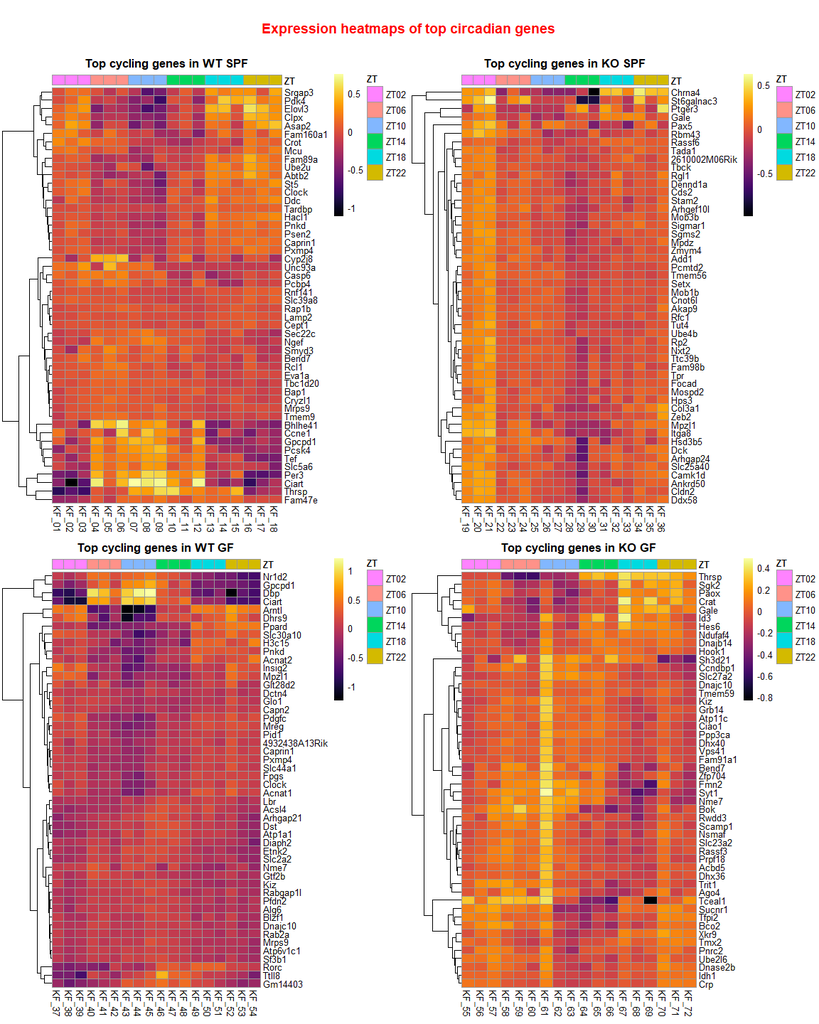

```r
fig <- ggarrange(as.ggplot(h1),as.ggplot(h2),as.ggplot(h3),as.ggplot(h4),
                 # labels = c("WT SPF", "KO SPF", "WT GF", "KO GF"),
                 ncol = 2, nrow = 2
                 )
annotate_figure(fig,
                top = text_grob("\nExpression heatmaps of top circadian genes\n",
                                color = "red", face = "bold", size = 14)
                )
```

## List sets

### Overview

The data can be imagined as sets.

- Let $\text{WT}_U$ be the set of all wild-type mice.
- Let $\text{KO}_U$ be the set of all L-Bmal1-KO mice.
- Let $\text{SPF}_U$ be the set of all specific pathogen free mice.
- Let $\text{GF}_U$ be the set of all germ-free mice.
- Let $WT\_SPF$ be the set of all genes $g$ such that $\{\,g \in WT\_SPF \mid g \in (\text{WT}_U \wedge \text{SPF}_U ) \wedge g \text{ is oscillating}\,\}$.
- Let $KO\_SPF$ be the set of all genes $g$ such that $\{\,g \in KO\_SPF \mid g \in (\text{KO}_U \wedge \text{SPF}_U ) \wedge g \text{ is oscillating}\,\}$.
- Let $WT\_GF$ be the set of all genes $g$ such that $\{\,g \in WT\_GF \mid g \in (\text{WT}_U \wedge \text{GF}_U ) \wedge g \text{ is oscillating}\,\}$.
- Let $KO\_GF$ be the set of all genes $g$ such that $\{\,g \in KO\_GF \mid g \in (\text{KO}_U \wedge \text{GF}_U ) \wedge g \text{ is oscillating}\,\}$.

Possible subsetted sets from each of the above sets can be interpreted in interesting ways in terms of pathway results from DAVID, e.g. the pathways that are oscillating in WT SPF mice, but not in their L-Bmal1-KO SPF counterparts, or pathways that are circadian in the SPF condition but not the GF condition, or pathways that are oscillating no matter the perturbation.

### Setup

Using [reticulate](https://rstudio.github.io/reticulate/articles/versions.html), a python source with pandas is needed.

Some python functions are sourced in `DAVID.py`.

```r
source_python("../py/DAVID.py")
```

Below is the the python source code.

`DAVID.py`

```python
import numpy as np
import pandas as pd

def unique_in_x_groups(df, colname, *args):
    """
    colname = the name of the column that will be compared between groups. Must be the same colname in all dataframes or else it will be skipped.
    df = dataframe being analyzed for uniques
    *args = dataframes being compared to df
    """
    totalList = pd.concat([x[colname] for x in args]).drop_duplicates().reset_index(drop=True)
    return([x for x in df[colname] if x not in totalList.tolist()])

def combine_x_groups(colname, *args):
    """
    returns a combination of all dataframes in *args. Colname must be the same in all dataframes.
    """
    return(pd.concat([x[colname] for x in args]).drop_duplicates().reset_index(drop=True))
```

### All within condition

These are the sets

- $WT\_SPF$ view
- $KO\_SPF$ view
- $WT\_GF$ view
- $KO\_GF$ view

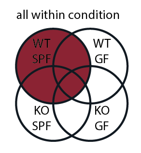

  <sup>*graphic of* $WT\_SPF$</sup>

```r
# All WT_SPF
data.frame(
  WT_SPF$ID[match(mouseProteinCodingGenes$ensembl_gene_id, WT_SPF$ID)],
    mouseProteinCodingGenes$external_gene_name, mouseProteinCodingGenes$description,
    WT_SPF$GammaBH[match(mouseProteinCodingGenes$ensembl_gene_id, WT_SPF$ID)]) %>%
  na.omit(.) %>%
  set_colnames(c('Geneid','external_gene_name','description', 'gamma_BH')) %>%
  .[match(WT_SPF$ID,.$Geneid),] %>%
  set_colnames(c('ensembl_ID','external_gene_name','description','gamma_BH')) %>%
  set_rownames(NULL) %>%
  write.xlsx2(., paste0(dataFolder,'all_within_condition/WT_SPF.xlsx'))

# All KO_SPF
data.frame(
  KO_SPF$ID[match(mouseProteinCodingGenes$ensembl_gene_id, KO_SPF$ID)],
    mouseProteinCodingGenes$external_gene_name, mouseProteinCodingGenes$description,
    KO_SPF$GammaBH[match(mouseProteinCodingGenes$ensembl_gene_id, KO_SPF$ID)]) %>%
  na.omit(.) %>%
  set_colnames(c('Geneid','external_gene_name','description', 'gamma_BH')) %>%
  .[match(KO_SPF$ID,.$Geneid),] %>%
  set_colnames(c('ensembl_ID','external_gene_name','description','gamma_BH')) %>%
  set_rownames(NULL) %>%
  write.xlsx2(., paste0(dataFolder,'all_within_condition/KO_SPF.xlsx'))

# All WT_GF
data.frame(
  WT_GF$ID[match(mouseProteinCodingGenes$ensembl_gene_id, WT_GF$ID)],
    mouseProteinCodingGenes$external_gene_name, mouseProteinCodingGenes$description,
    WT_GF$GammaBH[match(mouseProteinCodingGenes$ensembl_gene_id, WT_GF$ID)]) %>%
  na.omit(.) %>%
  set_colnames(c('Geneid','external_gene_name','description', 'gamma_BH')) %>%
  .[match(WT_GF$ID,.$Geneid),] %>%
  set_colnames(c('ensembl_ID','external_gene_name','description','gamma_BH')) %>%
  set_rownames(NULL) %>%
  write.xlsx2(., paste0(dataFolder,'all_within_condition/WT_GF.xlsx'))

# All KO_GF
data.frame(
  KO_GF$ID[match(mouseProteinCodingGenes$ensembl_gene_id, KO_GF$ID)],
    mouseProteinCodingGenes$external_gene_name, mouseProteinCodingGenes$description,
    KO_GF$GammaBH[match(mouseProteinCodingGenes$ensembl_gene_id, KO_GF$ID)]) %>%
  na.omit(.) %>%
  set_colnames(c('Geneid','external_gene_name','description', 'gamma_BH')) %>%
  .[match(KO_GF$ID,.$Geneid),] %>%
  set_colnames(c('ensembl_ID','external_gene_name','description','gamma_BH')) %>%
  set_rownames(NULL) %>%
  write.xlsx2(., paste0(dataFolder,'all_within_condition/KO_GF.xlsx'))
```

### Uniques

These are the sets:

- Let $WT\_SPF_U$ be the subset of $WT\_SPF$ such that $WT\_SPF - (KO\_SPF \cup WT\_GF \cup KO\_GF)$ view
- Let $KO\_SPF_U$ be the subset of $KO\_SPF$ such that $KO\_SPF - (WT\_SPF \cup WT\_GF \cup KO\_GF)$ view
- Let $WT\_GF_U$ be the subset of $WT\_GF$ such that $WT\_GF - (WT\_SPF \cup KO\_SPF \cup KO\_GF)$ view
- Let $KO\_GF_U$ be the subset of $KO\_GF$ such that $KO\_GF - (WT\_SPF \cup KO\_SPF \cup WT\_GF)$ view

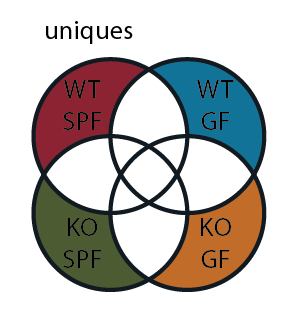

<sup>*graphic of uniques*</sup>

```r
# Unique WT_SPF
unique_in_x_groups(WT_SPF,'ID',KO_SPF,WT_GF,KO_GF) %>% data.frame() %>%
  {data.frame(
  .$.[match(mouseProteinCodingGenes$ensembl_gene_id, .$.)],
  mouseProteinCodingGenes$external_gene_name, mouseProteinCodingGenes$description,
  WT_SPF$GammaBH[match(mouseProteinCodingGenes$ensembl_gene_id, .$.)]
  )} %>%
  na.omit() %>%
  set_colnames(c('Geneid','external_gene_name','description', 'gamma_BH')) %>%
  arrange(as.numeric(as.character(gamma_BH))) %>%
  View()
  write.xlsx2(., paste0(dataFolder, 'uniques/WT_SPF.xlsx'))

# Unique KO_SPF
unique_in_x_groups(KO_SPF,'ID',WT_GF,KO_GF,WT_SPF) %>% data.frame() %>%
  {data.frame(
  .$.[match(mouseProteinCodingGenes$ensembl_gene_id, .$.)],
  mouseProteinCodingGenes$external_gene_name, mouseProteinCodingGenes$description,
  KO_SPF$GammaBH[match(mouseProteinCodingGenes$ensembl_gene_id, .$.)]
  )} %>%
  na.omit() %>%
  set_colnames(c('Geneid','external_gene_name','description', 'gamma_BH')) %>%
  arrange(as.numeric(as.character(gamma_BH))) %>%
  write.xlsx2(., paste0(dataFolder, 'uniques/KO_SPF.xlsx'))

# Unique WT_GF
unique_in_x_groups(WT_GF,'ID',KO_GF,WT_SPF,KO_SPF) %>% data.frame() %>%
  {data.frame(
  .$.[match(mouseProteinCodingGenes$ensembl_gene_id, .$.)],
  mouseProteinCodingGenes$external_gene_name, mouseProteinCodingGenes$description,
  WT_GF$GammaBH[match(mouseProteinCodingGenes$ensembl_gene_id, .$.)]
  )} %>%
  na.omit() %>%
  set_colnames(c('Geneid','external_gene_name','description', 'gamma_BH')) %>%
  arrange(as.numeric(as.character(gamma_BH))) %>%
  write.xlsx2(., paste0(dataFolder, 'uniques/WT_GF.xlsx'))

# Unique KO_GF
unique_in_x_groups(KO_GF,'ID',WT_SPF,KO_SPF,WT_GF) %>% data.frame() %>%
  {data.frame(
  .$.[match(mouseProteinCodingGenes$ensembl_gene_id, .$.)],
  mouseProteinCodingGenes$external_gene_name, mouseProteinCodingGenes$description,
  KO_GF$GammaBH[match(mouseProteinCodingGenes$ensembl_gene_id, .$.)]
  )} %>%
  na.omit() %>%
  set_colnames(c('Geneid','external_gene_name','description', 'gamma_BH')) %>%
  arrange(as.numeric(as.character(gamma_BH))) %>%
  write.xlsx2(., paste0(dataFolder, 'uniques/KO_GF.xlsx'))
```

### Shared

These are the sets:

- Let $\text{SPF}_n$ be the subset $WT\_SPF \cap KO\_SPF$ view
- Let $\text{GF}_n$ be the subset $WT\_GF \cap KO\_GF$ view
- Let $\text{WT}_n$ be the subset $WT\_SPF \cap WT\_GF$ view
- Let $\text{KO}_n$ be the subset $KO\_SPF \cap KO\_GF$ view

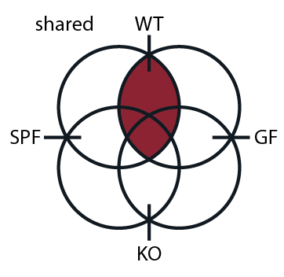

<sup>*graphic of* $\text{WT}_n$</sup>

```r
SPF_n <- merge(WT_SPF, KO_SPF, by=('ID')) %>%
  set_colnames(c('ID','WT_gamma_BH','KO_gamma_BH'))
GF_n <- merge(WT_GF, KO_GF, by=('ID')) %>%
  set_colnames(c('ID','WT_gamma_BH','KO_gamma_BH'))
WT_n <- merge(WT_SPF, WT_GF, by=('ID')) %>%
  set_colnames(c('ID','SPF_gamma_BH','GF_gamma_BH'))
KO_n <- merge(KO_SPF, KO_GF, by=('ID')) %>%
  set_colnames(c('ID','SPF_gamma_BH','GF_gamma_BH'))

# SPF
data.frame(
  SPF_n$ID[match(mouseProteinCodingGenes$ensembl_gene_id, SPF_n$ID)],
  mouseProteinCodingGenes$external_gene_name, mouseProteinCodingGenes$description,
  SPF_n$WT_gamma_BH[match(mouseProteinCodingGenes$ensembl_gene_id, SPF_n$ID)],
  SPF_n$KO_gamma_BH[match(mouseProteinCodingGenes$ensembl_gene_id, SPF_n$ID)]) %>%
  na.omit(.) %>%
  set_colnames(c('Geneid','external_gene_name','description')) %>%
  .[match(SPF_n$ID,.$Geneid),] %>%
  set_colnames(c('ensembl_ID','external_gene_name','description','WT_gamma_BH','KO_gamma_BH')) %>%
  set_rownames(NULL) %>%
  write.xlsx2(., paste0(dataFolder,'shared_within_condition/SPF_n.xlsx'))

# GF
data.frame(
  GF_n$ID[match(mouseProteinCodingGenes$ensembl_gene_id, GF_n$ID)],
  mouseProteinCodingGenes$external_gene_name, mouseProteinCodingGenes$description,
  GF_n$WT_gamma_BH[match(mouseProteinCodingGenes$ensembl_gene_id, GF_n$ID)],
  GF_n$KO_gamma_BH[match(mouseProteinCodingGenes$ensembl_gene_id, GF_n$ID)]) %>%
  na.omit(.) %>%
  set_colnames(c('Geneid','external_gene_name','description')) %>%
  .[match(GF_n$ID,.$Geneid),] %>%
  set_colnames(c('ensembl_ID','external_gene_name','description','WT_gamma_BH','KO_gamma_BH')) %>%
  set_rownames(NULL) %>%
  write.xlsx2(., paste0(dataFolder,'shared_within_condition/GF_n.xlsx'))

# WT
data.frame(
  WT_n$ID[match(mouseProteinCodingGenes$ensembl_gene_id, WT_n$ID)],
  mouseProteinCodingGenes$external_gene_name, mouseProteinCodingGenes$description,
  WT_n$SPF_gamma_BH[match(mouseProteinCodingGenes$ensembl_gene_id, WT_n$ID)],
  WT_n$GF_gamma_BH[match(mouseProteinCodingGenes$ensembl_gene_id, WT_n$ID)]) %>%
  na.omit(.) %>%
  set_colnames(c('Geneid','external_gene_name','description')) %>%
  .[match(WT_n$ID,.$Geneid),] %>%
  set_colnames(c('ensembl_ID','external_gene_name','description','SPF_gamma_BH','GF_gamma_BH')) %>%
  set_rownames(NULL) %>%
  write.xlsx2(., paste0(dataFolder,'shared_within_genotype/WT_n.xlsx'))

# KO
data.frame(
  KO_n$ID[match(mouseProteinCodingGenes$ensembl_gene_id, KO_n$ID)],
  mouseProteinCodingGenes$external_gene_name, mouseProteinCodingGenes$description,
  KO_n$SPF_gamma_BH[match(mouseProteinCodingGenes$ensembl_gene_id, KO_n$ID)],
  KO_n$GF_gamma_BH[match(mouseProteinCodingGenes$ensembl_gene_id, KO_n$ID)]) %>%
  na.omit(.) %>%
  set_colnames(c('Geneid','external_gene_name','description')) %>%
  .[match(KO_n$ID,.$Geneid),] %>%
  set_colnames(c('ensembl_ID','external_gene_name','description','SPF_gamma_BH','GF_gamma_BH')) %>%
  set_rownames(NULL) %>%
  write.xlsx2(., paste0(dataFolder,'shared_within_genotype/KO_n.xlsx'))
```

### genotype_unique and microbe_unique

**genetype_unique** are the sets:

- $(WT\_SPF \cap WT\_GF)^\mathsf{c}$
- $(KO\_SPF \cap KO\_GF)^\mathsf{c}$

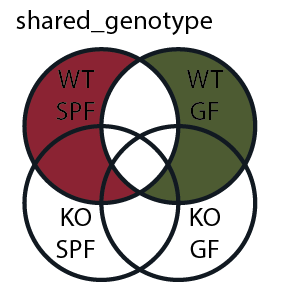

<sup>*graphic of* $(WT\_SPF \cap WT\_GF)^\mathsf{c}$</sup>

**microbe_unique** are the sets:

- $(WT\_SPF \cap KO\_SPF)^\mathsf{c}$
- $(WT\_GF \cap KO\_GF)^\mathsf{c}$

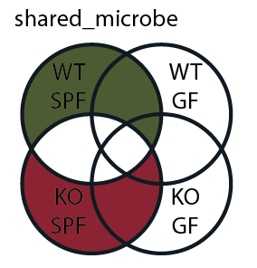

Since P values are assigned based on the first 4 sets, that is, $WT\_SPF$, $KO\_SPF$, $WT\_GF$, and $KO\_GF$, the above 4 sets can’t be made as 4 individual lists without many nonoverlapping genes.

Let $p_1$ be the p values given to all genes $g$ in the set $WT\_SPF$ such that $\exists\, p_1 \,(\,\forall\, g \in WT\_SPF)$.  
Let $p_2$ be the p values given to all genes $g$ in the set $KO\_SPF$ such that $\exists\, p_1 \,(\,\forall\, g \in KO\_SPF)$.  
Assume all genes are not unique, but all p values are unique.  
Since $WT\_SPF \ncong KO\_SPF$,  
$\neg\,\exists\, g \,(\,\forall\, p \in p_1 \cup p_2)$

Thus, there will be 8 lists:

- $WT\_SPF - WT\_GF$ `# WT_1` view
- $WT\_GF - WT\_SPF$ `# WT_2` view
- $KO\_SPF - KO\_GF$ `# KO_1` view
- $KO\_GF - KO\_SPF$ `# KO_2` view
- $WT\_SPF - KO\_SPF$ `# SPF_1` view
- $KO\_SPF - WT\_SPF$ `# SPF_2` view
- $WT\_GF - KO\_GF$ `# GF_1` view
- $KO\_GF - WT\_GF$ `# GF_2` view

These are equivalent, e.g $((WT\_SPF - WT\_GF) \cup WT\_GF - WT\_SPF) \cong (WT\_SPF \cap WT\_GF)^\mathsf{c}$

```r
# WT_1
WT_SPF %>%
  unique_in_x_groups("ID", WT_n) %>% data.frame() %>%
  {data.frame(
    .$.[match(mouseProteinCodingGenes$ensembl_gene_id, .$.)],
    mouseProteinCodingGenes$external_gene_name, mouseProteinCodingGenes$description,
    WT_SPF$GammaBH[match(mouseProteinCodingGenes$ensembl_gene_id, .$.)]
  )} %>%
  na.omit() %>%
  set_colnames(c('Geneid','external_gene_name','description','gamma_BH')) %>%
  arrange(as.numeric(as.character(gamma_BH))) %>%
  write.xlsx2(., paste0(dataFolder,'unique_genotype/WT_1.xlsx'))

# WT_2
WT_GF %>%
  unique_in_x_groups("ID", WT_n) %>% data.frame() %>%
  {data.frame(
    .$.[match(mouseProteinCodingGenes$ensembl_gene_id, .$.)],
    mouseProteinCodingGenes$external_gene_name, mouseProteinCodingGenes$description,
    WT_GF$GammaBH[match(mouseProteinCodingGenes$ensembl_gene_id, .$.)]
  )} %>%
  na.omit() %>%
  set_colnames(c('Geneid','external_gene_name','description','gamma_BH')) %>%
  arrange(as.numeric(as.character(gamma_BH))) %>%
  write.xlsx2(., paste0(dataFolder,'unique_genotype/WT_2.xlsx'))

# KO_1
KO_SPF %>%
  unique_in_x_groups("ID", KO_n) %>% data.frame() %>%
  {data.frame(
    .$.[match(mouseProteinCodingGenes$ensembl_gene_id, .$.)],
    mouseProteinCodingGenes$external_gene_name, mouseProteinCodingGenes$description,
    KO_SPF$GammaBH[match(mouseProteinCodingGenes$ensembl_gene_id, .$.)]
  )} %>%
  na.omit() %>%
  set_colnames(c('Geneid','external_gene_name','description','gamma_BH')) %>%
  arrange(as.numeric(as.character(gamma_BH))) %>%
  write.xlsx2(., paste0(dataFolder,'unique_genotype/KO_1.xlsx'))

# KO_2
KO_GF %>%
  unique_in_x_groups("ID", KO_n) %>% data.frame() %>%
  {data.frame(
    .$.[match(mouseProteinCodingGenes$ensembl_gene_id, .$.)],
    mouseProteinCodingGenes$external_gene_name, mouseProteinCodingGenes$description,
    KO_GF$GammaBH[match(mouseProteinCodingGenes$ensembl_gene_id, .$.)]
  )} %>%
  na.omit() %>%
  set_colnames(c('Geneid','external_gene_name','description','gamma_BH')) %>%
  arrange(as.numeric(as.character(gamma_BH))) %>%
  write.xlsx2(., paste0(dataFolder,'unique_genotype/KO_2.xlsx'))

# SPF_1
WT_SPF %>%
  unique_in_x_groups("ID", SPF_n) %>% data.frame() %>%
  {data.frame(
    .$.[match(mouseProteinCodingGenes$ensembl_gene_id, .$.)],
    mouseProteinCodingGenes$external_gene_name, mouseProteinCodingGenes$description,
    WT_SPF$GammaBH[match(mouseProteinCodingGenes$ensembl_gene_id, .$.)]
  )} %>%
  na.omit() %>%
  set_colnames(c('Geneid','external_gene_name','description','gamma_BH')) %>%
  arrange(as.numeric(as.character(gamma_BH))) %>%
  write.xlsx2(., paste0(dataFolder,'unique_microbe/SPF_1.xlsx'))

# SPF_2
KO_SPF %>%
  unique_in_x_groups("ID", SPF_n) %>% data.frame() %>%
  {data.frame(
    .$.[match(mouseProteinCodingGenes$ensembl_gene_id, .$.)],
    mouseProteinCodingGenes$external_gene_name, mouseProteinCodingGenes$description,
    KO_SPF$GammaBH[match(mouseProteinCodingGenes$ensembl_gene_id, .$.)]
  )} %>%
  na.omit() %>%
  set_colnames(c('Geneid','external_gene_name','description','gamma_BH')) %>%
  arrange(as.numeric(as.character(gamma_BH))) %>%
  write.xlsx2(., paste0(dataFolder,'unique_microbe/SPF_2.xlsx'))

# GF_1
WT_GF %>%
  unique_in_x_groups("ID", GF_n) %>% data.frame() %>%
  {data.frame(
    .$.[match(mouseProteinCodingGenes$ensembl_gene_id, .$.)],
    mouseProteinCodingGenes$external_gene_name, mouseProteinCodingGenes$description,
    WT_GF$GammaBH[match(mouseProteinCodingGenes$ensembl_gene_id, .$.)]
  )} %>%
  na.omit() %>%
  set_colnames(c('Geneid','external_gene_name','description','gamma_BH')) %>%
  arrange(as.numeric(as.character(gamma_BH))) %>%
  write.xlsx2(., paste0(dataFolder,'unique_microbe/GF_1.xlsx'))

# SPF_2
KO_GF %>%
  unique_in_x_groups("ID", GF_n) %>% data.frame() %>%
  {data.frame(
    .$.[match(mouseProteinCodingGenes$ensembl_gene_id, .$.)],
    mouseProteinCodingGenes$external_gene_name, mouseProteinCodingGenes$description,
    KO_GF$GammaBH[match(mouseProteinCodingGenes$ensembl_gene_id, .$.)]
  )} %>%
  na.omit() %>%
  set_colnames(c('Geneid','external_gene_name','description','gamma_BH')) %>%
  arrange(as.numeric(as.character(gamma_BH))) %>%
  write.xlsx2(., paste0(dataFolder,'unique_microbe/GF_2.xlsx'))
```

### Allgroups (intersect)

This is the set $WT\_SPF \cap KO\_SPF \cap WT\_GF \cap KO\_GF$. view

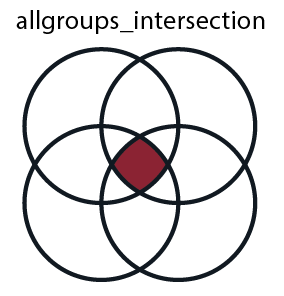

<sup>*graphic of* $WT\_SPF \cap KO\_SPF \cap WT\_GF \cap KO\_GF$.</sup>

```r
allgroups <- merge(WT_SPF, KO_SPF, by=('ID')) %>%
  set_colnames(c('ID','WT_SPF_gamma_BH','KO_SPF_gamma_BH')) %>%
  merge(., WT_GF, by='ID') %>%
  merge(., KO_GF, by='ID') %>%
  set_colnames(c('ID','WT_SPF_gamma_BH','KO_SPF_gamma_BH','WT_GF_gamma_BH','KO_GF_gamma_BH'))

# allgroups (intersect)
data.frame(
  allgroups$ID[match(mouseProteinCodingGenes$ensembl_gene_id, allgroups$ID)],
  mouseProteinCodingGenes$external_gene_name, mouseProteinCodingGenes$description,
  allgroups$WT_SPF_gamma_BH[match(mouseProteinCodingGenes$ensembl_gene_id, allgroups$ID)],
  allgroups$KO_SPF_gamma_BH[match(mouseProteinCodingGenes$ensembl_gene_id, allgroups$ID)],
  allgroups$WT_GF_gamma_BH[match(mouseProteinCodingGenes$ensembl_gene_id, allgroups$ID)],
  allgroups$KO_GF_gamma_BH[match(mouseProteinCodingGenes$ensembl_gene_id, allgroups$ID)]) %>%
  na.omit(.) %>%
  set_colnames(c('Geneid','external_gene_name','description')) %>%
  .[match(allgroups$ID,.$Geneid),] %>%
  set_colnames(c('ensembl_ID','external_gene_name','description','WT_SPF_gamma_BH','KO_SPF_gamma_BH','WT_GF_gamma_BH','KO_GF_gamma_BH')) %>%
  set_rownames(NULL) %>%
  write.xlsx2(., paste0(dataFolder,'allgroups_intersection.xlsx'))
```

### Allgroups (union)

This is the set $WT\_SPF \cup KO\_SPF \cup WT\_GF \cup KO\_GF$. view

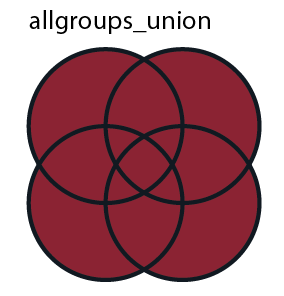

<sup>*graphic of* $WT\_SPF \cup KO\_SPF \cup WT\_GF \cup KO\_GF$.</sup>

```r
# all cycling genes
combine_x_groups('ID',WT_SPF,KO_SPF,WT_GF,KO_GF) %>% data.frame() %>%
  {data.frame(
  .$.[match(mouseProteinCodingGenes$ensembl_gene_id, .$.)],
  mouseProteinCodingGenes$external_gene_name, mouseProteinCodingGenes$description
  )} %>%
  na.omit() %>%
  set_colnames(c('Geneid','external_gene_name','description')) %>%
  arrange(Geneid) %>%
  write.xlsx2(., paste0(dataFolder, 'allgroups_union.xlsx'))
```

# TODO

Analyses with these lists are ongoing in DAVID and Metascape. In the future, they may or may not be useful in the other pipeline (DESeq2/Limorhyde/fGSEA).

By [Sumeed Yoyo Manzoor](https://github.com/yoyomanzoor/)

*smanzoor@uchicago.edu*